# dada2 Single-End Protocol - Boston_run1

Seth M. Bloom

Februari 18, 2022

### Researchers/collaborators:

- Gabriella Edfeldt gabriella.edfeldt@ki.se
- Jiawu Xu jxu25@mgjh.harvard.edu
- Douglas S. Kwon dkwon@mgh.harvard.edu

## References:

- Callahan, B. J., McMurdie, P. J., Rosen, M. J., Han, A. W., Johnson, A. J. A., & Holmes, S. P. (2016). DADA2: High-resolution sample inference from Illumina amplicon data. Nature Methods, 13(7), 581–3.
  - https://doi.org/10.1038/nmeth.3869
- McMurdie, P. J., & Holmes, S. (2013). phyloseq: an R package for reproducible interactive analysis and graphics of microbiome census data. PloS One, 8(4), e61217.
  - https://doi.org/10.1371/journal.pone.0061217
- DADA2 tutorial: http://benjjneb.github.io/dada2/tutorial.html
- DADA2 big data tutorial: http://benjjneb.github.io/dada2/bigdata.html
- Phyloseq: https://joey711.github.io/phyloseq/index.html
- Qiime 1 Mapping files: http://qiime.org/documentation/file_formats.html#mapping-file-overview

### Sequencing run parameters and metrics (Boston run 1 only)

**RUN PARAMETERS (from RunParameters.xml MiSeq output file)**

- Sequencing Date: **2019_02_25**
- Run ID: **190225M05907 0033 000000000-C8CH9**
- Sequencer: **Instrument M05907**
- Run type: **Single-end V2 300x1 kit (e.g. Single-end V2 300x1 kit)**
- Flow cell information: **Serial number: 000000000-C8CH9 Exp.Date: 2019_10_26**
- PR2 Buffer information: **Serial number: MS7625117-00PR2 Exp.Date: 2019_11_04**
- Reagent kit information: **Serial number: MS7731647-300V2 Exp.Date: 2019_10_05**

**RUN METRICS (From Illumina BaseSpace record of the run, https://basespace.illumina.com/home/index )**

## Expected output

1. A knitted R markdown document (default format is HTML, but can also select options including PDF or MSWord) that contains all comments, code, and figures produced. Key highlights include:
   - The document returns the names of any samples that failed to pass filter and were eliminated from the final output tables and phyloseq output.
   - The document calculates and returns cumulative processing time at various steps along the analysis.
2. Filtered reads with quality information for each sample stored in newly created subdirectory /Data/filtered.
   - If sequence files were originally named **samplename**.fastq, the corresponding filtered files will be named **samplename**.filt.fastq
3. A newly created subdirectory named /Output containing:
   - Plot of aggregated read quality scores from the {plot-unfiltered-run-quality} chunk
   - Plot(s) of read quality scores for individual sample(s) (if code for these plots is included in the {plot-unfiltered-run-quality} chunk)
   - Plot of error rates from the {learn-errors} chunk
   - Table of read counts and percentages retained after each sequence analysis step for each sample, saved in a .txt file in TSV format (can be opened in Excel)
   - Plot of read percentages retained after each sequence analysis step for each sample
4. A newly created subdirectory named /ps_objects containing a different phyloseq object for each taxonomic database used. Each phyloseq object is created in the {create-phyloseq} chunk and contains:
   - An otu_table (ASV table) based on amplicon sequence variants (ASVs) after dada sequence inference and chimera removal
   - A tax_table based on taxonomic assignments performed in the {assign-taxonomy} chunk
   - sample_data derived from the mapping file.
   - Phylogenetic trees are not constructed because depending on the type of sample sequenced, they may not be relevant (e.g. in vitro synthetic mixtures of laboratory bacterial strains for QC)
5. A newly created subdirectory named /RDS containing:
   - An RDS file containing the sequence table after chimera removal.
   - An RData workspaced imaging saving the final workspace for the analysis.

```r
knitr::opts_knit$set(root.dir = getwd())
```

```r
#Define variable with start time of running script.
start_time <- proc.time()
```

```r
# Load libraries
library(ShortRead)
packageVersion("ShortRead")
## [1] '1.44.0'
library(dada2)
packageVersion("dada2")
## [1] '1.14.0'
library("phangorn")
packageVersion("phangorn")
## [1] '2.7.0'
library("phyloseq")
packageVersion("phyloseq")
## [1] '1.30.0'
library("ips")
packageVersion("ips")
## [1] '0.0.11'
library("tidyverse")
packageVersion("tidyverse")
## [1] '1.2.1'

# Set random seed for reproducibility purposes
set.seed(100)
```

```r
if(params$run=="Boston_run1"){
  run.name <- "Boston_run1"
  run.date <-  "2019_02_25_v1"
  mapping_file <- "Mapping_info_Boston_run1.csv"
  # Trim read lenght left and right
  FwdTrimLeft <- 10
  FwdTrimRight <- 225
}

if(params$run=="Boston_run2"){
  run.name <- "Boston_run2"
  run.date <-  "2019_05_25"
  mapping_file <- "Mapping_info_Boston_run2.csv"
  # Trim read lenght left and right
  FwdTrimLeft <- 0
  FwdTrimRight <- 252
}

# Sequencing run date in format YYYY_MM_DD
print("Sequencing run date and version:")
run.date
```

```
## [1] "Sequencing run date and version:"
## [1] "2019_02_25_v1"
```

```r
# if(params$run=="Boston_run1"){
#   url <- c(
#     "ftp://ftp.sra.ebi.ac.uk/vol1/fastq/SRR919/001/SRR9198521/SRR9198521.fastq.gz",
#     "ftp://ftp.sra.ebi.ac.uk/vol1/fastq/SRR919/007/SRR9198517/SRR9198517.fastq.gz",
#     "ftp://ftp.sra.ebi.ac.uk/vol1/fastq/SRR919/008/SRR9198518/SRR9198518.fastq.gz"
#     ) }
# dir <- "../data/Fastq"
# dir.create(dir)
# purrr::walk(url, ~download.file(.x, file.path("../data/Fastq/", basename(.x)), method="auto"))
# system("gunzip ../data/Fastq/*.gz")
#

if(params$run == "Boston_run1"){dir  <- "/Users/vilkal/Raw_data/Microbiome/Run1_Boston_CVLv3_March2019"}
if(params$run == "Boston_run2"){dir <- "/Users/vilkal/Raw_data/Microbiome/Run2_Boston_Tissuev3_June2019"}

files <- list.files(path = dir, pattern =".fastq$", full.names = T, recursive = T)
```

### Filter and trim reads

```r
#Define and print path to working directory
pathwd <- getwd()
print("Working directory:")
pathwd

# Define path to subdirectory containing demultiplexed forward-read fastq files
pathF <- file.path("../data/Fastq")
print("Directory containing raw demultiplexed .fastq sequence files:")
pathF

#Define path to directory containing 16S databases
print("Path to 16S databases:")
pathdb <- file.path("../Resources/RDP_database")
pathdb

#Define path to directory containing mapping file
print("Path to mapping file:")
pathMap <- file.path("../data/Mapping")
pathMap

#Create and define path to subdirectory in which filtered files will be stored
filtpathF <- file.path("../data/Fastq/filtered")
print("Directory that will contain filtered .fastq files:")
filtpathF
dir.create(filtpathF)

#Create and define path to subdirectory in which to store output figures and tables
print("Directory in which to store output figures and tables:")
pathOut <- file.path("../results/dada2_output")
pathOut
dir.create(pathOut)

#Create and define path to subdirectory in which RDS files will be stored
print("Path to directory for saving RDS files:")
pathF.RDS <- file.path(pathOut, "RDS")
pathF.RDS
dir.create(pathF.RDS)

#Create and define path to subdirectory in which RDS files containing phyloseq objects will be stored
print("Path to sub-directory in which to save phyloseq objects:")
pathps0 <- file.path(pathOut, "ps_objects")
pathps0
dir.create(pathps0)
```

```
## [1] "Working directory:"
## [1] "/Users/vilkal/work/Brolidens_work/Projects/broliden_5325/reports"
## [1] "Directory containing raw demultiplexed .fastq sequence files:"
## [1] "../data/Fastq"
## [1] "Path to 16S databases:"
## [1] "../Resources/RDP_database"
## [1] "Path to mapping file:"
## [1] "../data/Mapping"
## [1] "Directory that will contain filtered .fastq files:"
## [1] "../data/Fastq/filtered"
## [1] "Directory in which to store output figures and tables:"
## [1] "../results/dada2_output"
## [1] "Path to directory for saving RDS files:"
## [1] "../results/dada2_output/RDS"
## [1] "Path to sub-directory in which to save phyloseq objects:"
## [1] "../results/dada2_output/ps_objects"
```

```r
# File parsing
#Create vector of fastq files in pathF.directory
#If analyzing paired end reads, the search pattern below would need to be modified (see DADA2 tutorial)

print("Sequence files to be analyzed:")
fnFs <- sort(files)
head(fnFs)

#Extract sample names, assuming filenames have format: SAMPLENAME.fastq or SAMPLENAME.fastq.gz
sample.names <- sapply(strsplit(basename(fnFs), ".fast"), `[`, 1)
head(sample.names)
```

```
## [1] "Sequence files to be analyzed:"
## [1] "/Users/vilkal/Raw_data/Microbiome/Run1_Boston_CVLv3_March2019/Luminal_fastq_files/1872.022.rcbc214.2019.02.25.fastq"
## [2] "/Users/vilkal/Raw_data/Microbiome/Run1_Boston_CVLv3_March2019/Luminal_fastq_files/1907.032.rcbc226.2019.02.25.fastq"
## [3] "/Users/vilkal/Raw_data/Microbiome/Run1_Boston_CVLv3_March2019/Luminal_fastq_files/1954.043.rcbc238.2019.02.25.fastq"
## [4] "/Users/vilkal/Raw_data/Microbiome/Run1_Boston_CVLv3_March2019/Luminal_fastq_files/1996.054.rcbc250.2019.02.25.fastq"
## [5] "/Users/vilkal/Raw_data/Microbiome/Run1_Boston_CVLv3_March2019/Luminal_fastq_files/2051.064.rcbc262.2019.02.25.fastq"
## [6] "/Users/vilkal/Raw_data/Microbiome/Run1_Boston_CVLv3_March2019/Luminal_fastq_files/2140.110.rcbc320.2019.02.25.fastq"
## [1] "1872.022.rcbc214.2019.02.25" "1907.032.rcbc226.2019.02.25"
## [3] "1954.043.rcbc238.2019.02.25" "1996.054.rcbc250.2019.02.25"
## [5] "2051.064.rcbc262.2019.02.25" "2140.110.rcbc320.2019.02.25"
```

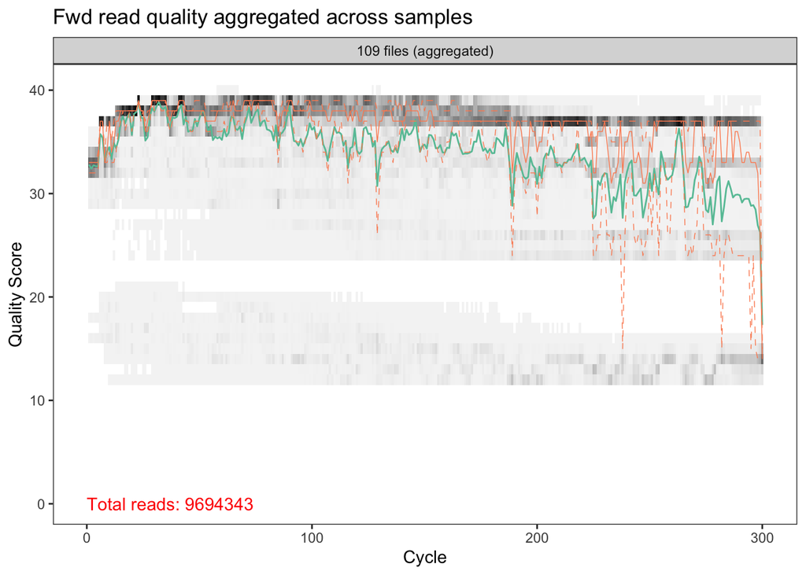

```r
#Plot forward read quality aggregated across all forward read files
p.qual.f.1.agg <- plotQualityProfile(fnFs, aggregate = TRUE) +
  ggtitle("Fwd read quality aggregated across samples")
p.qual.f.1.agg
```

```r
#Save figure to file
ggsave(filename = file.path(pathOut, paste0("Read_quality_aggregate_fwd_", run.date, ".pdf")),
       plot = p.qual.f.1.agg, device = "pdf", width = 8, height = 6, units = "in")
```

```r
#Calculate cumulative processing time
print("Cumulative processing time (seconds):")
proc.time() - start_time
```

```
## [1] "Cumulative processing time (seconds):"
##    user  system elapsed
## 168.697   9.304 179.063
```

## Define positions at which to trim filtered data

```r
## ## ## ## ## ## ## ## ## ##
## USER INPUT REQUIRED HERE ##
## ## ## ## ## ## ## ## ## ##

# Define base positions at which to trim the filtered forward read sequences
# Decisions about where to trim should be based on the quality profile above.
# See DADA2 tutorial for additional information.
# The two variable defined here will then be supplied to the filterAndTrim function
  # FwdTrimLeft gives the posion from the left margin at which to trim
  # FwdTrimRight gives the position from the right margin at which to trim
# For example if FwdTrimLeft is 10 and FwdTrimRight is 240, sequence lengths will be 230 bp.

print(paste0("Trimming forward reads on left at base position ", FwdTrimLeft,
       " and on right at base position ", FwdTrimRight))
```

```
## [1] "Trimming forward reads on left at base position 10 and on right at base position 225"
```

## Quality filter and trim

```r
# Create vector of modified names of fastq files after filtering in
# which the modified file name changes from "samplename.fastq"
# to "samplename.filt.fastq"

filtFs <- file.path(filtpathF, str_replace(basename(fnFs), "(.fastq)", ".filt\\1"))
head(filtFs)

# Filter and trim sequences listed in fnFs and store them in filtFs,
# while storing summary in dataframe out

out <- filterAndTrim(fwd = fnFs, filt = filtFs, rev = NULL, filt.rev = NULL,
              trimLeft = FwdTrimLeft, truncLen = c(FwdTrimRight), maxEE = 2, truncQ = 11, maxN = 0,
              rm.phix = TRUE, compress = TRUE, verbose = TRUE, multithread = TRUE)
head(out)
#truncate file extension (".fastq" or ".fastq.gz") from rownames
rownames(out) <- rownames(out) %>% str_replace(".fast.+", "")
head(out)
```

```
## [1] "../data/Fastq/filtered/1872.022.rcbc214.2019.02.25.filt.fastq"
## [2] "../data/Fastq/filtered/1907.032.rcbc226.2019.02.25.filt.fastq"
## [3] "../data/Fastq/filtered/1954.043.rcbc238.2019.02.25.filt.fastq"
## [4] "../data/Fastq/filtered/1996.054.rcbc250.2019.02.25.filt.fastq"
## [5] "../data/Fastq/filtered/2051.064.rcbc262.2019.02.25.filt.fastq"
## [6] "../data/Fastq/filtered/2140.110.rcbc320.2019.02.25.filt.fastq"
##                                   reads.in reads.out
## 1872.022.rcbc214.2019.02.25.fastq   110022     99554
## 1907.032.rcbc226.2019.02.25.fastq    67306     61170
## 1954.043.rcbc238.2019.02.25.fastq   114558    100639
## 1996.054.rcbc250.2019.02.25.fastq    73017     68506
## 2051.064.rcbc262.2019.02.25.fastq   157822    136551
## 2140.110.rcbc320.2019.02.25.fastq    32169     29611
##                             reads.in reads.out
## 1872.022.rcbc214.2019.02.25   110022     99554
## 1907.032.rcbc226.2019.02.25    67306     61170
## 1954.043.rcbc238.2019.02.25   114558    100639
## 1996.054.rcbc250.2019.02.25    73017     68506
## 2051.064.rcbc262.2019.02.25   157822    136551
## 2140.110.rcbc320.2019.02.25    32169     29611
```

```r
# Calculate cumulative processing time
print("Cumulative processing time (seconds):")
proc.time() - start_time
```

```
## [1] "Cumulative processing time (seconds):"
##    user  system elapsed
## 912.166  43.663 268.712
```

## Sequence inference

```r
## Set paramaters
# Create character of all files in directory filtpathF.1 (i.e. all filtered files)
# with names including string "fastq" (i.e. all *.fastq and *.fastq.gz files)
filtFs.pass <- list.files(filtpathF, pattern="fastq", full.names = TRUE)
head(filtFs.pass)

# Create character vector of sample names from the file names in filtFs.1
# This code assumes all filename = "samplename.filt.fastq"" or "samplename.filt.fastq.gz""
sample.names.filt.pass <- sapply(strsplit(basename(filtFs.pass), ".filt.fast"), `[`, 1)
head(sample.names.filt.pass)

# Name the elements in filtFs according to the elements in sample.names.filt
names(filtFs.pass) <- sample.names.filt.pass

# Samples for which no sequences passed the filtering step
print("Samples for which no sequences passed filter criteria (i.e. samples excluded from filtered dataset):")
sample.names.filt.fail <- setdiff(sample.names, sample.names.filt.pass)
sample.names.filt.fail
```

```
## [1] "../data/Fastq/filtered/101u6866T.165.rcbc179.2019.06.10.filt.fastq"
## [2] "../data/Fastq/filtered/105u7143T.166.rcbc183.2019.06.10.filt.fastq"
## [3] "../data/Fastq/filtered/107u7152T.167.rcbc185.2019.06.10.filt.fastq"
## [4] "../data/Fastq/filtered/108u5343T.168.rcbc186.2019.06.10.filt.fastq"
## [5] "../data/Fastq/filtered/10u8310T.009.rcbc009.2019.06.10.filt.fastq"
## [6] "../data/Fastq/filtered/111u7150T.169.rcbc189.2019.06.10.filt.fastq"
## [1] "101u6866T.165.rcbc179.2019.06.10" "105u7143T.166.rcbc183.2019.06.10"
## [3] "107u7152T.167.rcbc185.2019.06.10" "108u5343T.168.rcbc186.2019.06.10"
## [5] "10u8310T.009.rcbc009.2019.06.10"  "111u7150T.169.rcbc189.2019.06.10"
## [1] "Samples for which no sequences passed filter criteria (i.e. samples excluded from filtered dataset):"
## character(0)
```

```r
# Set random seed for reproducibility purposes
set.seed(100)

# Learn forward read error rates
errF <- learnErrors(filtFs.pass, nread=1e6, multithread=TRUE, randomize = "TRUE")
```

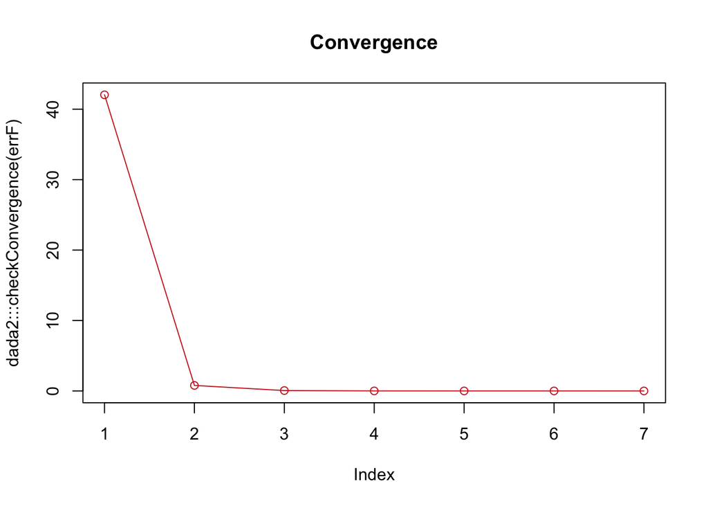

```r
# Plot convergence of error rate computation
plot(dada2:::checkConvergence(errF), type = "o", col = "firebrick3", main = "Convergence")
```

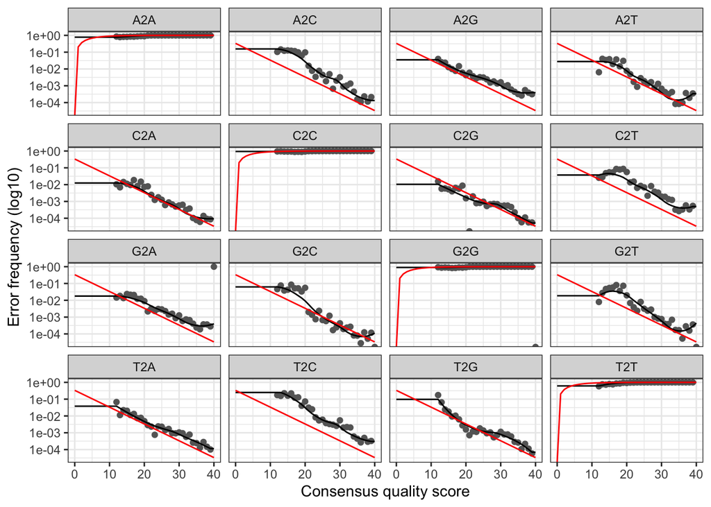

```r
# Plot calculated errors
p.err.F <- plotErrors(errF, nominalQ = TRUE)
p.err.F
```

```r
# Save figure to file
ggsave(filename = file.path(pathOut, paste0("Error_rates_fwd_", run.date, ".pdf")),
       plot = p.err.F, device = "pdf", width = 8, height = 6, units = "in")
```

[output not shown]

```r
#Calculate cumulative processing time
print("Cumulative processing time (seconds):")
proc.time() - start_time
```

```
## [1] "Cumulative processing time (seconds):"
##     user   system  elapsed
## 1677.122   56.091  416.242
```